# Proyecto Final de Probabilidad y Estadística

Heidy Valdelamar Gonzalez

2022-11-23

Heijdra et al. afirman que muchos pacientes con enfermedad pulmonar obstructiva crónica (EPOC) grave presentan una saturación arterial de oxígeno baja durante la noche. Estos investigadores realizaron un estudio para determinar si existe una relación causal entre la disfunción de los músculos respiratorios y la saturación nocturna.

Los sujetos fueron 20 (5 mujeres, 15 hombres) pacientes con EPOC asignados aleatoriamente a recibir un entrenamiento muscular inspiratorio de flujo objetivo (TF-IMT) al 60 por ciento de su presión bucal inspiratoria máxima (PImáx) o un TF-IMT simulado al 10 por ciento de la PImáx. La presión inspiratoria máxima (PIM) se genera al realizar una inspiración máxima (aspirar el aire exterior hacia los pulmones), desde el volumen residual en condiciones estáticas, con el cual se determina la fuerza del diafragma.

Entre los datos recogidos estaban los tiempos de resistencia (Tiempo, s) de cada sujeto al inicio del entrenamiento y 10 semanas después.

- Aplique una de las técnicas no paramétricas.
- Aplique una de las técnicas de ANOVA.
- Formular las hipótesis pertinentes, realizar las pruebas adecuadas y hallar los valores p.
- Indique las decisiones estadísticas y las conclusiones clínicas que justifican los resultados de sus pruebas de hipótesis.
- Describa la(s) población(es) a la(s) que cree que son aplicables sus inferencias.
- Indique los supuestos necesarios para la validez de sus análisis.

# Hipótesis.

Si existe una relación causal entre la disfunción de los músculos respiratorios y la saturación nocturna, entonces los pacientes que recibieron un entrenamiento muscular inspiratorio de flujo objetivo (TF-IMT) al 10 y 60 porciento de su presión bucal inspiratoria máxima (PImáx) con EPOC presentarán un incremento de resistencia al final del entrenamiento.

Por lo tanto, la hipótesis nula es que H0 : promedio semana 0 - semana 10 > 0

Por lo tanto, la hipótesis alternativa es que HA : promedio semana 0 - semana 10 <= 0

# Captura de los datos

Llamamos a las librerías que usaremos:

```r
library("car")
library("emmeans")
library("rstatix")
library("tidyverse")
```

```r
library("ggplot2")
library("coin")
library("ggpubr")
library("ggstatsplot")
```

Leemos base de datos:

```r
datos <- read_csv(file="REV_C13_25.csv", show_col_types = FALSE)
datos
```

| week0 | week10 | GROUP |
| --- | --- | --- |
| 330 | 544 | 1 |
| 400 | 590 | 1 |
| 720 | 624 | 1 |
| 249 | 330 | 1 |
| 144 | 369 | 1 |
| 440 | 789 | 1 |
| 440 | 459 | 1 |
| 289 | 529 | 1 |
| 819 | 1099 | 1 |
| 540 | 930 | 1 |

[output cut: 10 more lines]

# Comparación de Resistencia por semanas de cada grupo

- El grupo 1 corresponde a los pacientes de (PI máx) al 60 porciento.
- El grupo 2 corresponde a los pacientes de (PI máx) al 10 porciento.

Filtramos los datos para cada grupo:

```r
#Grupo 1
g1 <- datos %>% filter(GROUP ==1)
g1 <- subset(g1,
             select = c(week0, week10))
#Grupo 2
g2 <- datos %>% filter(GROUP == 2)
g2 <- subset(g2,
             select = c(week0, week10))
```

Para hacer una prueba t usando notación de fórmula de nuestra hipótesis se necesitan alargar los datos.

```r
#Elongamos los datos para g1
g1_long <- g1 %>%
  pivot_longer(cols = c("week0","week10"),
               names_to = "Semanas",
               values_to = "Resistencia")

g1_long <- g1_long %>%
  mutate( Semanas = Semanas %>%
            fct_relevel("week0","week10"))

# Estimación de las medianas y sus cuantiles
g1_long %>%
  group_by(Semanas) %>%
  get_summary_stats(Resistencia, type = "median_iqr")
```

| Semanas | variable | n | median | iqr |
| --- | --- | --- | --- | --- |
| week0 | Resistencia | 10 | 420 | 215.75 |
| week10 | Resistencia | 10 | 567 | 271.25 |

Se van a transformar los datos de tabla a formato “largo” por un comando de pivot_longer(). Y se usará la librería ggstatsplot para graficar los datos y los resultados de la prueba t.

```r
#Elongamos los datos para g2

g2_long <- g2 %>%
  pivot_longer(cols = c("week0","week10"),
               names_to = "Semanas",
               values_to = "Resistencia")

g2_long <- g2_long %>%
  mutate( Semanas = Semanas %>%
            fct_relevel("week0","week10"))
# Estimación de las medianas y sus cuantiles
g2_long %>%
  group_by(Semanas) %>%
  get_summary_stats(Resistencia, type = "median_iqr")
```

| Semanas | variable | n | median | iqr |
| --- | --- | --- | --- | --- |
| week0 | Resistencia | 10 | 440.0 | 153 |
| week10 | Resistencia | 10 | 421.5 | 161 |

## Boxplot

Grupo 1

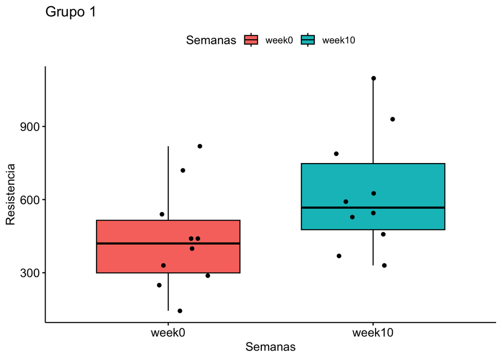

```r
ggboxplot(g1_long, x = "Semanas", y = "Resistencia", add = "jitter", fill = "Semanas")+
  ggtitle("Grupo 1")
```

Grupo 2

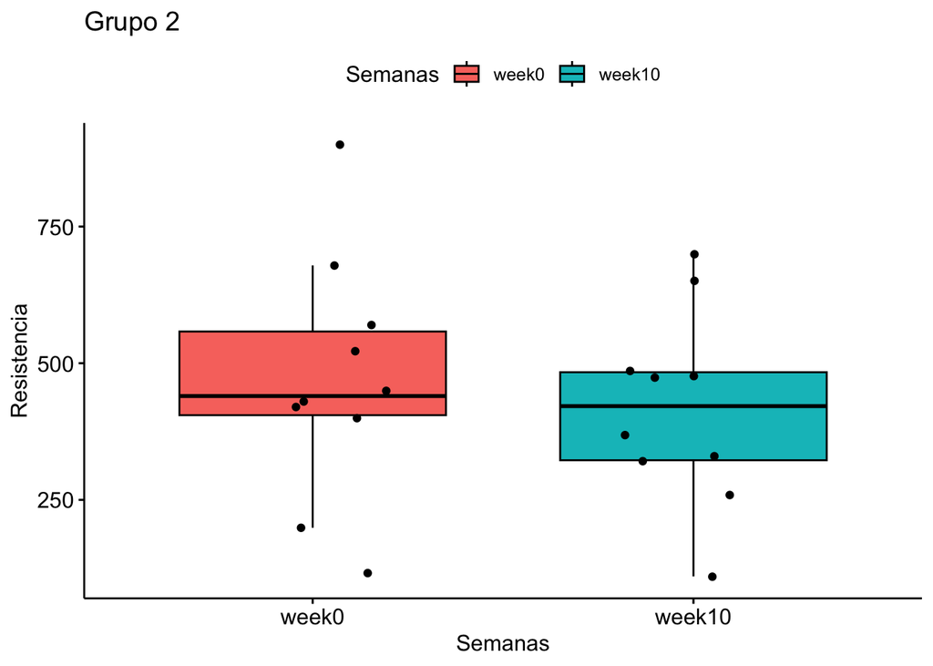

```r
ggboxplot(g2_long, x = "Semanas", y = "Resistencia", add = "jitter", fill = "Semanas")+
  ggtitle("Grupo 2")
```

## ANOVA

El análisis de varianza se usa principalmente para dos propósitos:

1. para estimar y desarrollar prueba de hipótesis de varianzas de una población.
2. Estimar y probar medias poblacionales.

### ANOVA del grupo 1

```r
g1_aov <- aov(Resistencia ~ Semanas, data=g1_long)

summary(g1_aov)
```

```
##             Df Sum Sq Mean Sq F value Pr(>F)
## Semanas      1 178983  178983   3.448 0.0798 .
## Residuals   18 934255   51903
## ---
## Signif. codes:  0 '***' 0.001 '**' 0.01 '*' 0.05 '.' 0.1 ' ' 1
```

Tabla de media:

```r
model.tables(g1_aov, type="means")
```

```
## Tables of means
## Grand mean
##
## 531.7
##
##  Semanas
## Semanas
##  week0 week10
##  437.1  626.3
```

Tabla de efecto:

```r
model.tables(g1_aov, type="effects")
```

```
## Tables of effects
##
##  Semanas
## Semanas
##  week0 week10
##  -94.6   94.6
```

### ANOVA del grupo 2

```r
g2_aov <- aov(Resistencia ~ Semanas, data=g2_long)

summary(g2_aov)
```

```
##             Df Sum Sq Mean Sq F value Pr(>F)
## Semanas      1  13107   13107   0.322  0.578
## Residuals   18 733785   40766
```

Tabla de media:

```r
model.tables(g2_aov, type="means")
```

```
## Tables of means
## Grand mean
##
## 443
##
##  Semanas
## Semanas
##  week0 week10
##  468.6  417.4
```

Tabla de efecto:

```r
model.tables(g2_aov, type="effects")
```

```
## Tables of effects
##
##  Semanas
## Semanas
##  week0 week10
##   25.6  -25.6
```

## Test Tukey HSD

El Test HSD (Honestly-significant-difference) de Tukey es un test de comparaciones múltiples. Permite comparar las medias de los t niveles de un factor después de haber rechazado la Hipótesis nula de igualdad de medias mediante la técnica ANOVA. Es, por lo tanto, un test que trata de perfilar, trata de especificar, una Hipótesis alternativa genérica como la de cualquiera de los Test ANOVA.

### Grupo 1

```r
TukeyHSD(g1_aov)
```

```
##   Tukey multiple comparisons of means
##     95% family-wise confidence level
##
## Fit: aov(formula = Resistencia ~ Semanas, data = g1_long)
##
## $Semanas
##               diff       lwr     upr    p adj
## week10-week0 189.2 -24.85303 403.253 0.079754
```

Gráfica de comparación de la prueba Tukey:

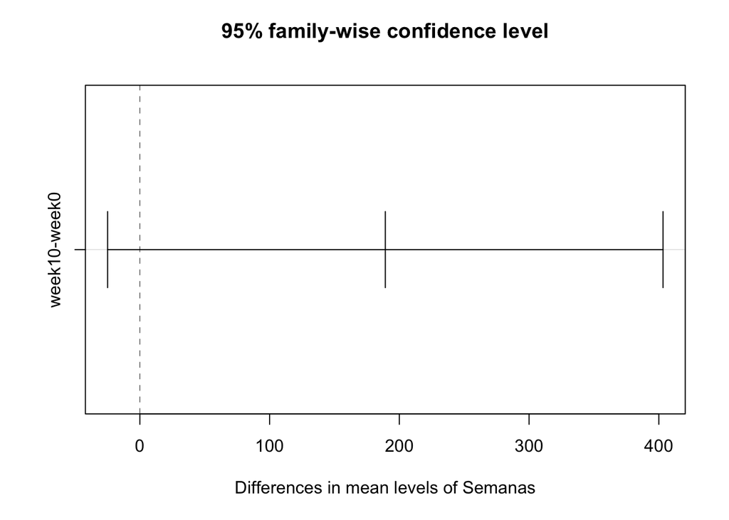

```r
plot(TukeyHSD(g1_aov))
```

### Grupo 2

```r
TukeyHSD(g2_aov)
```

```
##   Tukey multiple comparisons of means
##     95% family-wise confidence level
##
## Fit: aov(formula = Resistencia ~ Semanas, data = g2_long)
##
## $Semanas
##               diff       lwr      upr     p adj
## week10-week0 -51.2 -240.9025 138.5025 0.5776966
```

Gráfica de comparación de la prueba Tukey:

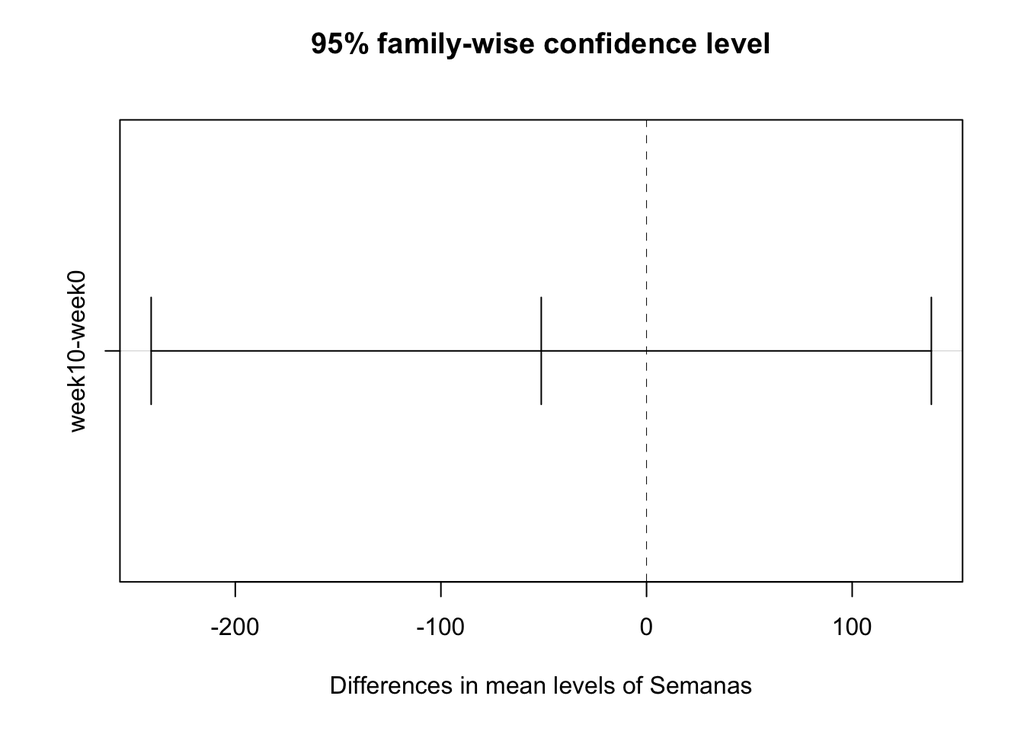

```r
plot(TukeyHSD(g2_aov))
```

## Prueba de Kruskal Wallis (técnica no paramétrica)

El sustituto no paramétrico de la prueba ANOVA de una vía, es la prueba categórica de Kruskal-Wallis. La hipótesis nula es que las medidas centrales del todas las muestras están alineadas (son “iguales”).

### Grupo 1

```r
g1_stat.test <- kruskal_test(Resistencia ~ Semanas, data = g1_long)
g1_stat.test
```

```
##
##  Asymptotic Kruskal-Wallis Test
##
## data:  Resistencia by Semanas (week0, week10)
## chi-squared = 3.4352, df = 1, p-value = 0.06382
```

### Grupo 2

```r
g2_stat.test <- kruskal_test(Resistencia ~ Semanas, data = g2_long)
g2_stat.test
```

```
##
##  Asymptotic Kruskal-Wallis Test
##
## data:  Resistencia by Semanas (week0, week10)
## chi-squared = 0.28, df = 1, p-value = 0.5967
```

## Prueba de Hipótesis: Comparaciones pareadas (t pareada)

### Prueba T pareada

La prueba t pareada es un método que se usa para comprobar si la media entre pares de medidas es o no igual a cero.

Uno de los parámetros estimados por ggwithinstats es el tamaño del efecto por la estadística g de Hedge expresa la diferencia entre los promedios de las poblaciones en unidades de la desviación estándar combinada (pooled standard deviation).

#### Grupo 1

```r
t.test(Resistencia ~ Semanas, data = g1_long, alternative = "less", mu=0, paired = TRUE, var.equal = TRUE, conf.level = 0.95)
```

```
##
##  Paired t-test
##
## data:  Resistencia by Semanas
## t = -4.0076, df = 9, p-value = 0.001538
## alternative hypothesis: true mean difference is less than 0
## 95 percent confidence interval:
##       -Inf -102.6581
## sample estimates:
## mean difference
##          -189.2
```

Graficamos los resultados:

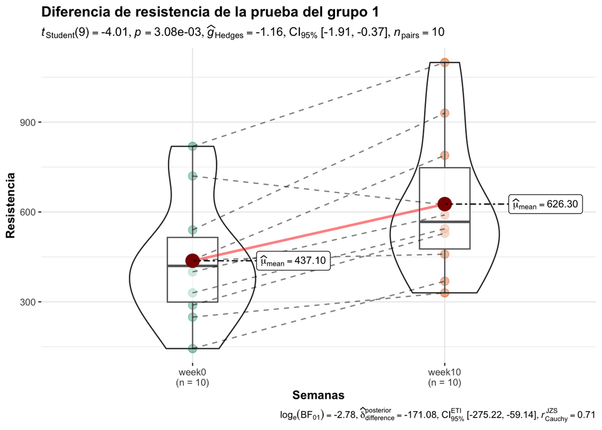

```r
ggwithinstats(
  data = g1_long, x = Semanas, y = Resistencia,
  title = "Diferencia de resistencia de la prueba del grupo 1",
  plot.type = "violin",
  type = "parametric",
  pairwise.comparisons = TRUE,
  pairwise.display = "significant",
  p.adjust.method = "holm",
  conf.level = 0.95,
  var.equal = TRUE)
```

#### Grupo 2

```r
t.test(Resistencia ~ Semanas, data = g2_long, alternative = "less", mu=0, paired = TRUE, var.equal = TRUE, conf.level = 0.95)
```

```
##
##  Paired t-test
##
## data:  Resistencia by Semanas
## t = 1.3236, df = 9, p-value = 0.8909
## alternative hypothesis: true mean difference is less than 0
## 95 percent confidence interval:
##      -Inf 122.1098
## sample estimates:
## mean difference
##            51.2
```

Graficamos los resultados:

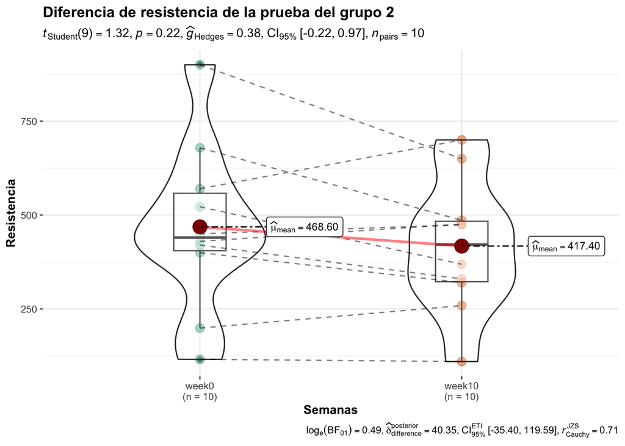

```r
ggwithinstats(
  data = g2_long, x = Semanas, y = Resistencia,
  title = "Diferencia de resistencia de la prueba del grupo 2",
  plot.type = "violin",
  type = "parametric",
  pairwise.comparisons = TRUE,
  pairwise.display = "significant",
  p.adjust.method = "holm",
  conf.level = 0.95,
  var.equal = TRUE)
```